## Reproducible Research | Peer-graded Assignment: Course Project 1

=================================

This assignment consists in answer the following questions

### 1.Loading and preprocessing the data

**Load the data.** First the existence of the data in the directory will be checked. Otherwise, the data is downloaded and unzipped

```r
file_url <- "https://d396qusza40orc.cloudfront.net/repdata%2Fdata%2Factivity.zip"
zip_file <- ".\\repdata_data_activity.zip"
if (!file.exists(zip_file)) {
        download.file(file_url, destfile = zip_file, mode = 'wb')
        date_download <- date()
}
file_name <-".\\activity.csv"
if (!file.exists(file_name)) {
        unzip(zipfile = zip_file, exdir = getwd())
}

activity_data <- read.csv(file_name, header = TRUE)
```

**The data must be transformed (if necessary) for its proper treatment.** In this case, the date must be transformed from character type to date type

```r
activity_data$date <- as.Date(activity_data$date, format = "%Y-%m-%d")
original_data <- activity_data
```

### 2.What is mean total number of steps taken per day?

For now, you can ignore the missing values in the dataset.

```r
activity_data<- na.omit(activity_data)
```

Build a histogram of the total number of steps per day.

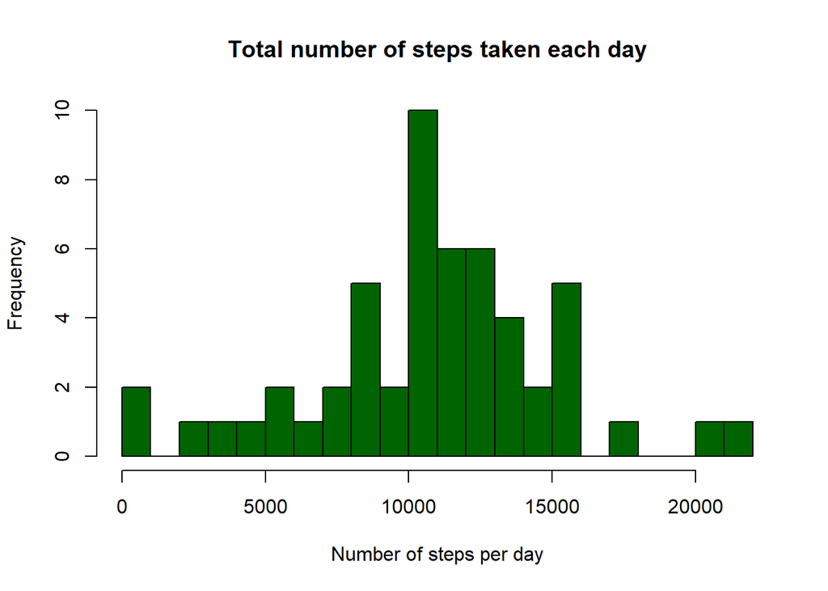

```r
total_steps_per_day <- aggregate(steps ~ date, data = activity_data, FUN = sum)
hist(total_steps_per_day$steps,
     main = "Total number of steps taken each day",
     xlab = "Number of steps per day",
     col = "darkgreen",
     breaks = 30)
```

**Calculate the mean and median of total number of steps taken per day.**

The mean total number of steps taken per day:

```r
mean_number_steps <- mean(total_steps_per_day$steps)
mean_number_steps
```

```
## [1] 10766.19
```

The median total number of steps taken per day:

```r
median_number_steps <- median(total_steps_per_day$steps)
median_number_steps
```

```
## [1] 10765
```

### 3.What is the average daily activity pattern?

**Make a time series plot of the 5-minute interval (x-axis) and the average number of steps taken, averaged across all days (y-axis)**

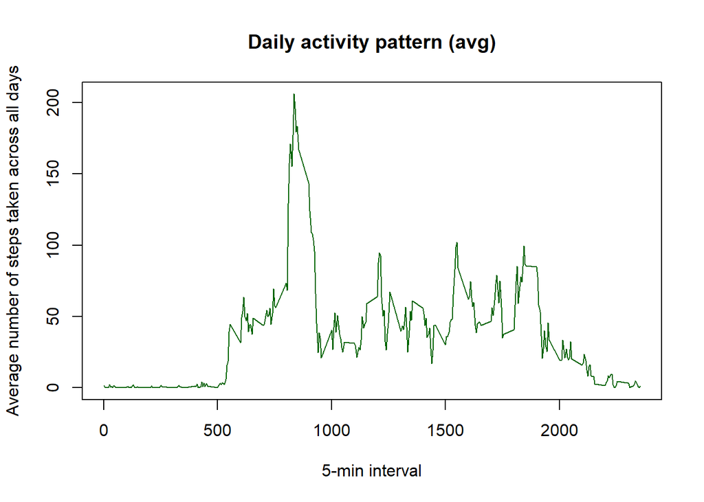

```r
avg_steps_per_interval <- aggregate(steps ~ interval, data = activity_data, FUN = mean)
plot(x = avg_steps_per_interval$interval,
     y = avg_steps_per_interval$steps,
     type = "l",
     col = "darkgreen",
     xlab = "5-min interval",
     ylab = "Average number of steps taken across all days",
     main = "Daily activity pattern (avg)")
```

Now, we’ll determine Which 5-minute interval, on average across all the days in the dataset, contains the maximum number of steps.

```r
five_min_interval <- avg_steps_per_interval$interval[which.max(avg_steps_per_interval$steps)]
print(paste("Maximum number of steps is", five_min_interval))
```

```
## [1] "Maximum number of steps is 835"
```

### 4.Imputing missing values

Exist a number of missing values that could introduce variations in the calculations. Therefore, we will determine its relevance

**Calculate the total number of missing values in the dataset (Total number of rows with NAs)**

```r
na_steps <- sum(is.na(original_data$steps))
print(paste("The total number of missing values is",na_steps))
```

```
## [1] "The total number of missing values is 2304"
```

**The choice is replace the missing values in the dataset for the mean for that 5-minute interval.**

```r
avg_for_5min_interval <- aggregate(steps ~ interval, data = original_data, FUN = mean, na.rm = TRUE)
```

**So, replacing the missing data with the mean for that 5-minute interval, we will get the following expression**

```r
# replNA_data is the new dataset where we'll replace NA steps
replNA_data <- original_data

is_na_steps <- is.na(original_data$steps)
aux <- na.omit(subset(avg_for_5min_interval, interval == original_data$interval[is_na_steps]))
replNA_data$steps[is_na_steps] <- aux[, 2]
na_steps_replNA <- sum(is.na(replNA_data))
print(paste("The number of NAs after replace is",na_steps_replNA))
```

```
## [1] "The number of NAs after replace is 0"
```

**Now, we’ll build a histogram of the total number of steps taken each day.**

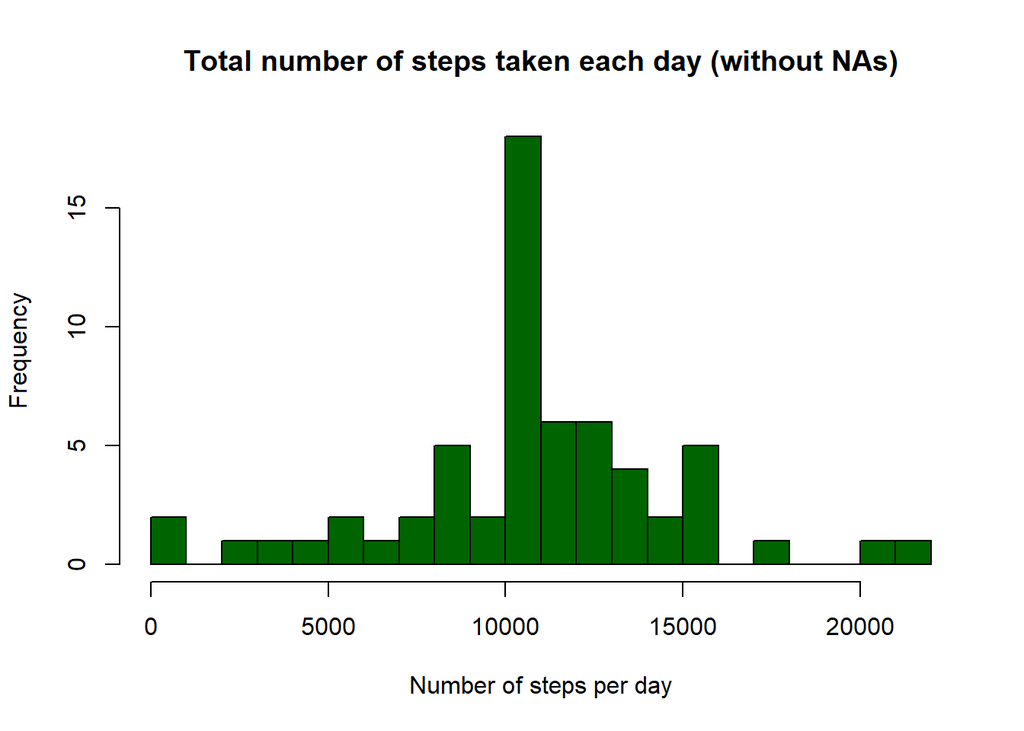

```r
steps_per_day_noNA <- aggregate(steps ~ date, data = replNA_data, FUN = sum, na.rm = TRUE)
hist(steps_per_day_noNA$steps,
     main = "Total number of steps taken each day (without NAs)",
     xlab = "Number of steps per day",
     col = "darkgreen",
     breaks = 30)
```

**Calculate the mean and median total number of steps taken per day.**

```r
mean_steps_per_day <- mean(steps_per_day_noNA$steps)
print(paste("The mean of total number of steps taken per day is:",mean_steps_per_day))
```

```
## [1] "The mean of total number of steps taken per day is: 10766.1886792453"
```

```r
median_steps_per_day <- median(steps_per_day_noNA$steps)
print(paste("The median of total number of steps taken per day is:",median_steps_per_day))
```

```
## [1] "The median of total number of steps taken per day is: 10766.1886792453"
```

**Are these values different from the estimates from the first part of the assignment?**

Both mean and median was really close values at the begining of the excercise. So, after replace the NAs values, the median was slightly increase becoming equal to the mean.

**What is the impact of imputing missing data on the estimates of the total daily number of steps?**

The summary of the original data set is:

```r
summary(total_steps_per_day$steps)
```

```
##    Min. 1st Qu.  Median    Mean 3rd Qu.    Max.
##      41    8841   10765   10766   13294   21194
```

The summary of the data set with missing values replaced is:

```r
summary(steps_per_day_noNA$steps)
```

```
##    Min. 1st Qu.  Median    Mean 3rd Qu.    Max.
##      41    9819   10766   10766   12811   21194
```

There are quite significant differences in the quartiles, with an increasing in the 1st Quartile and an decreasing in the 3rd Quartile.

**Are there differences in activity patterns between weekdays and weekends?**

Now, the weekdays() function could be helpful. We’ll use the dataset with the replaced missing values for this part.

We’ll create a new factor variable in the dataset in two levels – “weekday” and “weekend” indicating whether a given date is a weekday or weekend day.

```r
weekdays_values = c('segunda-feira', 'terça-feira', 'quarta-feira', 'quinta-feira', 'sexta-feira')
date_type <- ifelse(
                weekdays(replNA_data$date) %in% weekdays_values,
                'weekday',
                'weekend')
replNA_data$day <- factor(x = date_type)
```

We’ll build a panel plot containing a time series plot (i.e. type = “l”) of the 5-minute interval (x-axis) and the average number of steps taken, averaged across all weekday days or weekend days (y-axis). Let’s take a look:

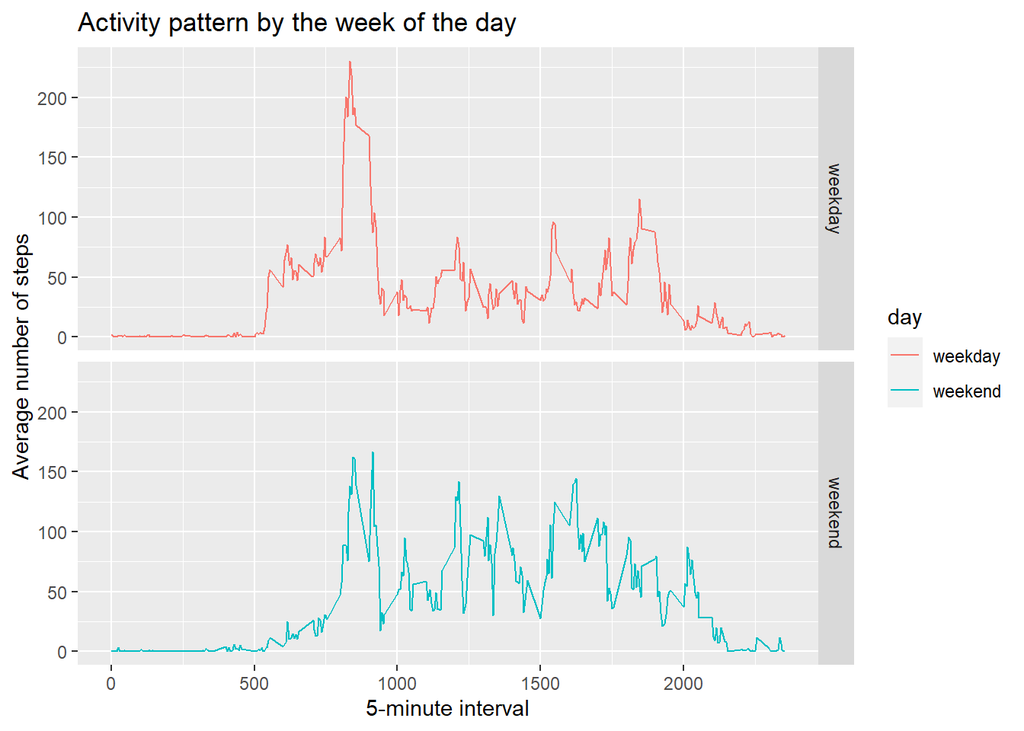

```r
avg_steps_per_weekday <- aggregate(steps ~ interval + day, data = replNA_data, FUN = mean, na.rm = TRUE)

library(ggplot2)
ggplot(avg_steps_per_weekday, aes(interval, steps, color = day)) +
       geom_line() +
       facet_grid(day ~ .) +
       xlab('5-minute interval') +
       ylab('Average number of steps') +
       ggtitle('Activity pattern by the week of the day ')
```